# progetto di Data Science

## Introduzione alle domande

La mia presentazione consite nell’analizazione dei livelli di obesità nelle personne dei paesi del Messico, del perù e della colombia.

1-Fattori di Rischio:  
- Quali sono i principali fattori di rischio associati all’obesità ?  
- Come differiscono questi fattori tra diverse categorie di persone ?

2-Stili di Vita:  
- Quali abitudini di vita che sono associate a un maggior rischio di obesità?  
- Come possono variare queste abitudini tra gruppi demografici diversi?

## Presentazione del Dataset

Ho estratto il dataset su kaggle : Obesity or CVD risk (Classify/Regressor/Cluster) che contiene i dati sulla stima dei livelli di obesità nelle personne.  
L’ho scelto dopo aver visualizzato tanti altri dataset perchè contiene variabile importantanti per questo analisi come:

. Genere ,Età ,Categorie di peso , Storia famigliale con Sovrappeso  
. Gli atributi legati alle abitudine alimentari  
. Gli atributi relativa alla condizione fisica

Il raporto tra l’altezza e il peso è principali fattori di rischio associati all’obesità?  
si! Come differisce questo fattori tra diverse categorie di persone ?

## Rapporto tra il peso e l’altezza in funzione dell’indice di massa corporea

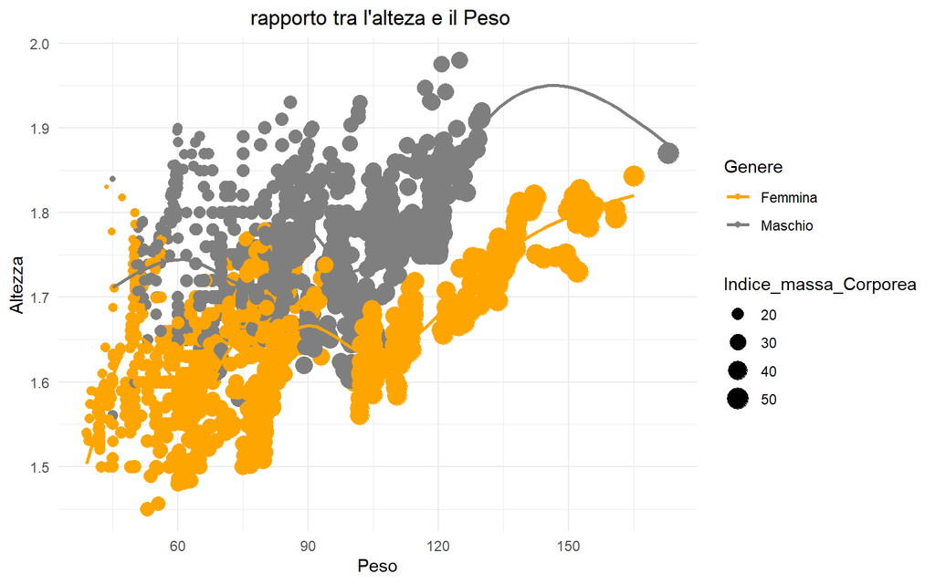

## Rapporto tra l’indice di massa corporea e la storia familiare con sovrappeso

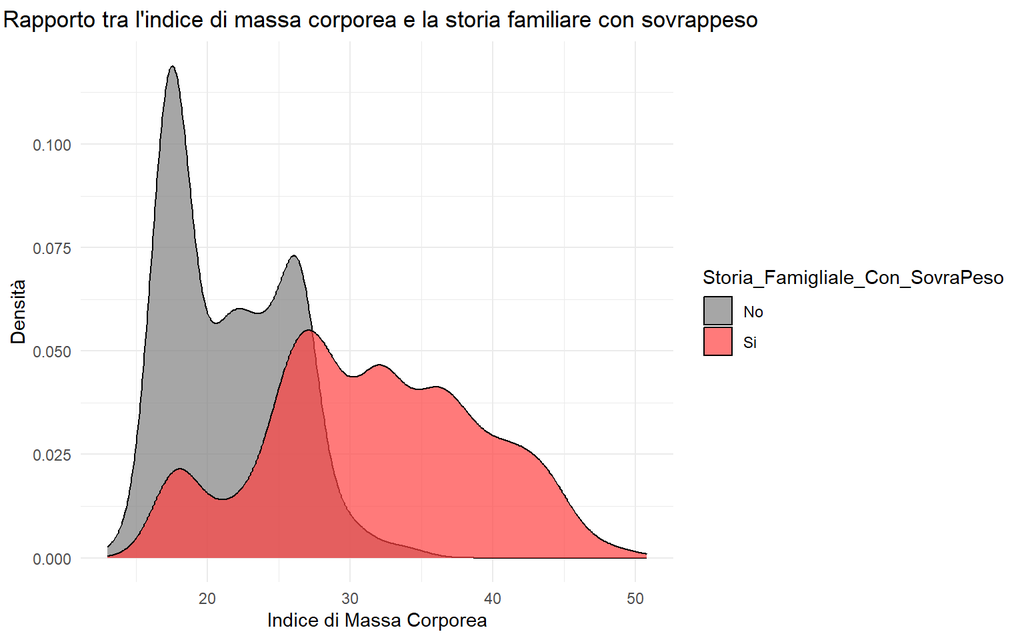

## Percentuale delle personne con storia famigliale con sovrappeso per categorie di peso

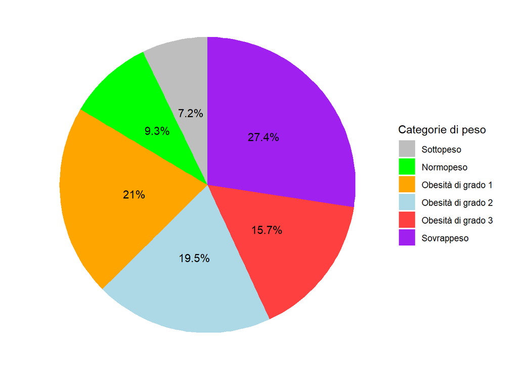

c’è un rischio elevato da chi ha una storia famigliale con sovrappeso di avere l’obesità

le abitudine alimentari sono associate a un maggior rischio di obesità? si! Come possono variare queste abitudini tra gruppi demografici diversi?

## Percentuale di consumo frequente di alimenti ad alto contenuto calorico per categorie di peso

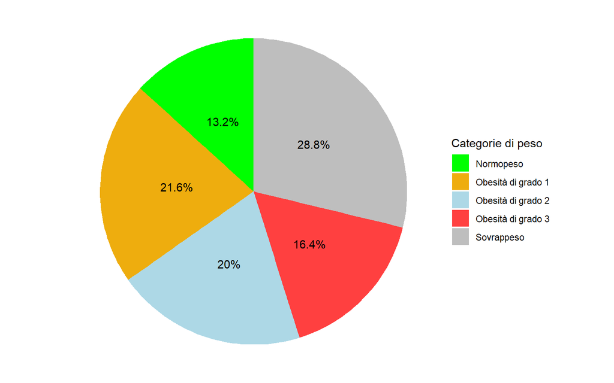

## Consumo frequente di alimenti ad alto contenuto calorico per genere

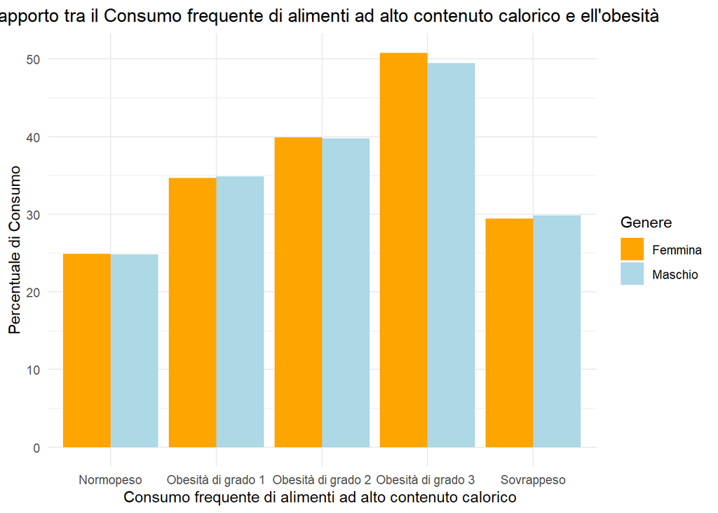

il consumo di alimenti ad alto contenuto calorico non sembra essere diversso per le categorie di genere però si presenta come un fattore di obesità

## Rapporto tra fumare e l’obesità

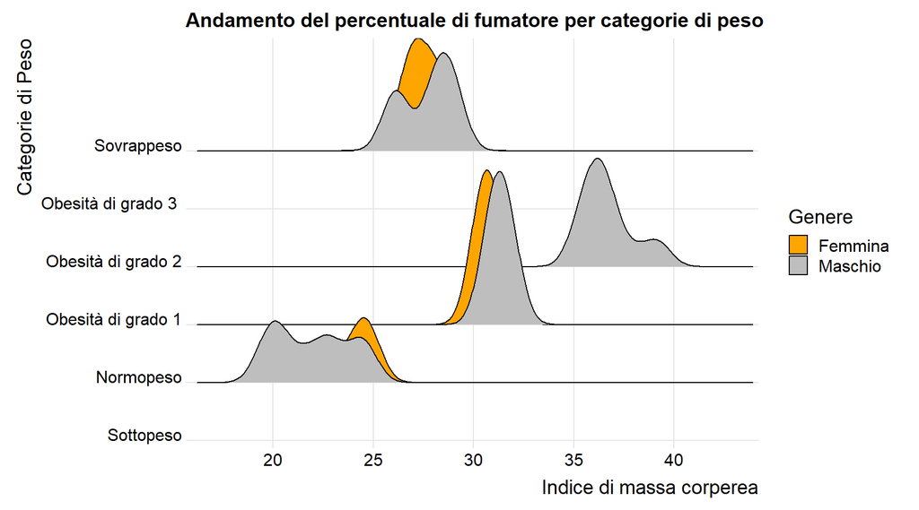

atributi relativa alla condizione fisica sono associate a un maggior rischio di obesità?  
si! Come possono variare queste abitudini tra gruppi demografici diversi?

## Frequenza di attività fisica media per le categorie di peso

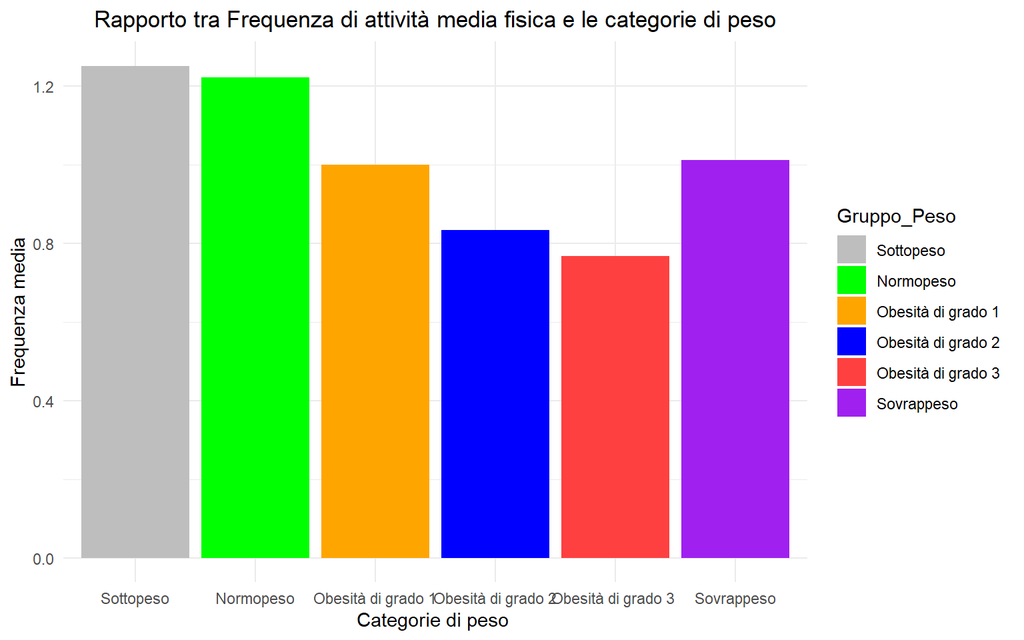

la frequenza di attiità è basso da quelli con obesità grave mentre l’intervallo di età che ha più rischio di obesità con frequenza di attività media < 0.7 è quello dei giovani < 40

## Rapporto tra la frequenza di attività fisica media per intervalli di età

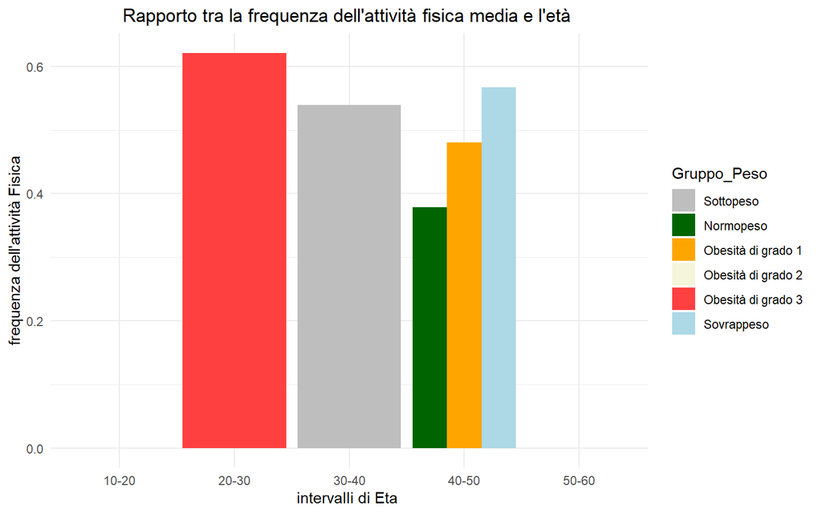

## Mezzo di trasporto utilizzato dalle personne con obesità grave

[figure not shown]

## conclusione

Questo progetto mi ha aiutato molto aumentando la mia conoscenza della scienza dei data, soprattuto analizzando questi dati ho imparato di più sui rischi e sui fattori dell’obesità.